# Analyse descriptive des données opportunistes du GMB

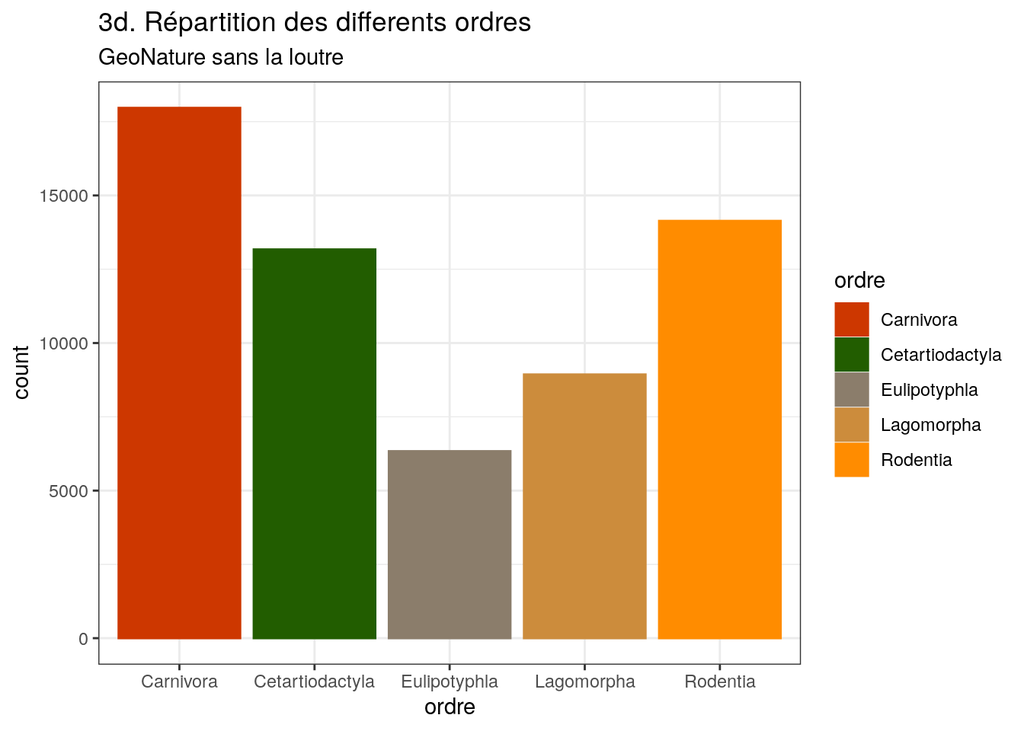

Nous nous sommes demandés à quoi ressemblerait la répartition des ordres sans la loutre car elle est une espèce dont le GMB se préoccupe beaucoup. Ca ne change pas drastiquement la distribution.

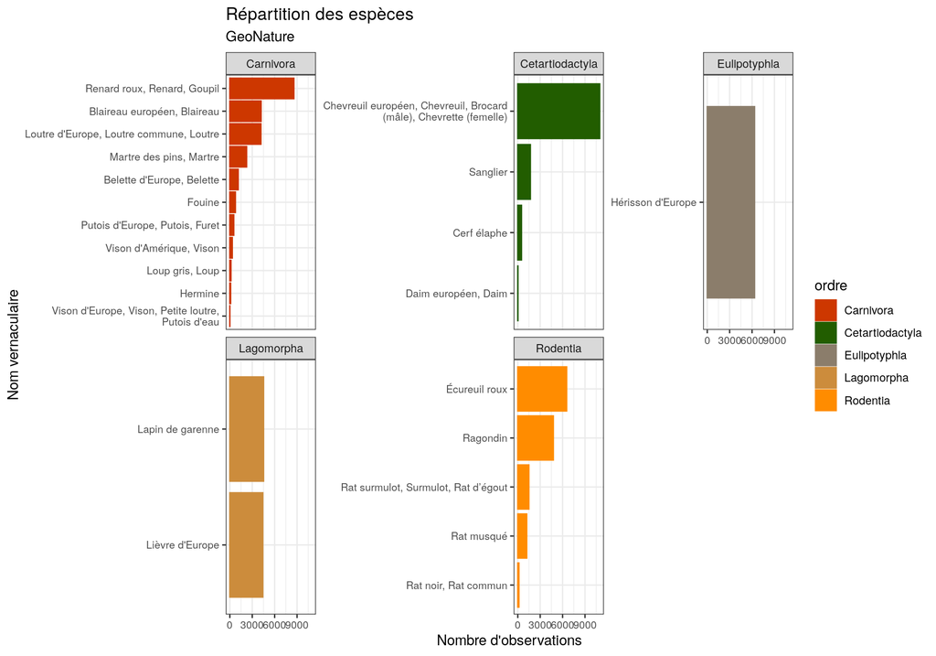

```r
Total%>%
  filter(date > params$date_min,
         bdd_originale == GN)%>%
  count(nom_vernaculaire, ordre, sort = TRUE) %>%
  ggplot(aes(x = reorder(nom_vernaculaire, n),
             y = n, fill = ordre, color = ordre)) +
  geom_col() +
  coord_flip() +
  facet_wrap(~ ordre, scales = "free_y") +
  labs(
    title = "Répartition des espèces",
        subtitle = paste(GN),
    y = "Nombre d'observations", x = "Nom vernaculaire"
  ) +
  scale_x_discrete(labels = label_wrap(40)) +
  theme_bw()+
  theme(axis.text=element_text(size=8))+
  scale_colour_manual(values=couleur)+
  scale_fill_manual(values = couleur)
```

[figure not shown]

```r
Total%>%
  filter(date > params$date_min,
         bdd_originale == GN)%>%
  count(nom_vernaculaire, ordre, sort = TRUE) %>%
  ggplot(aes(x = reorder(nom_vernaculaire, n),
             y = n, fill = ordre, color = ordre)) +
  geom_col() +
  coord_flip() +
  facet_wrap(~ ordre, scales = "free_y") +
  labs(
    title = "Répartition des espèces",
        subtitle = paste(GN),
    y = "Nombre d'observations", x = "Nom vernaculaire"
  ) +
  scale_x_discrete(labels = label_wrap(40)) +
  theme_bw()+
  theme(axis.text=element_text(size=8))+
  scale_colour_manual(values=couleur)+
  scale_fill_manual(values = couleur)
```

## 1.2 2. Description temporelle des bases de données

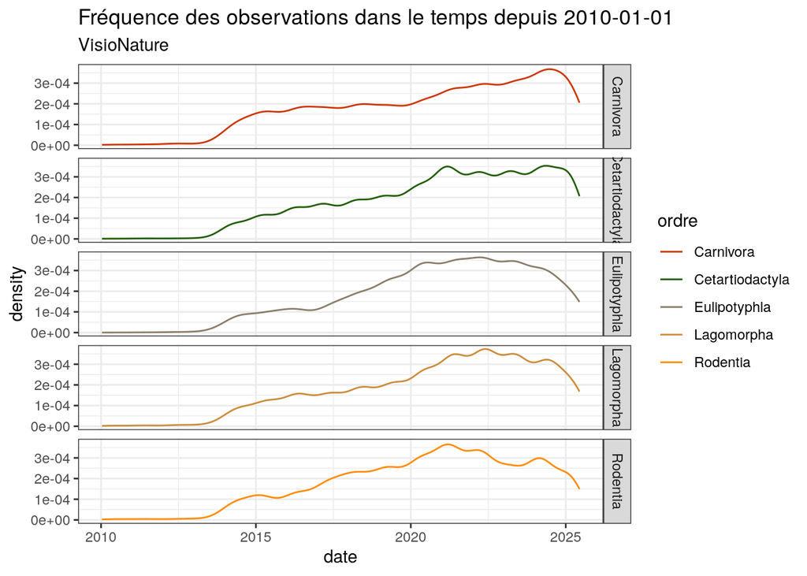

```r
Total%>%
  filter(date > params$date_min,
         bdd_originale == VN)%>%
  ggplot(aes(date, color = ordre))+
  labs(title=paste("Fréquence des observations dans le temps depuis", params$date_min),
       subtitle = paste(VN))+
  facet_grid(ordre ~ .)+
  theme_bw()+
  geom_line(stat="density")+
  scale_colour_manual(values=couleur)
```

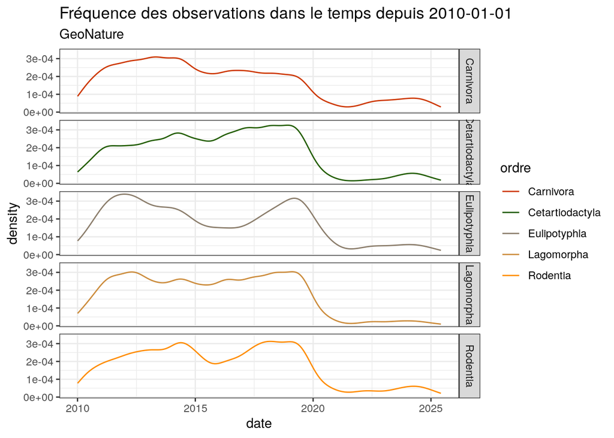

```r
Total%>%
  filter(date > params$date_min,
         bdd_originale == GN)%>%
  ggplot(aes(date, color = ordre))+
  labs(title=paste("Fréquence des observations dans le temps depuis", params$date_min),
       subtitle = paste(GN))+
  facet_grid(ordre ~ .)+
  theme_bw()+
  geom_line(stat="density")+
  scale_colour_manual(values=couleur)
```

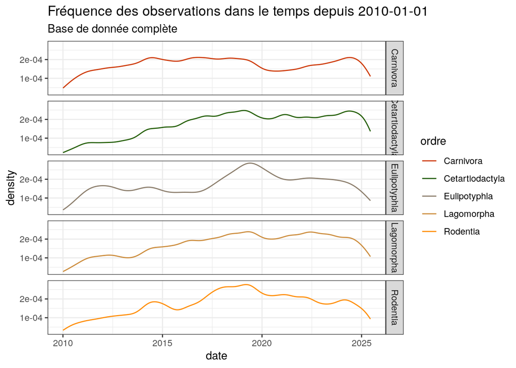

```r
Total%>%
  filter(date > params$date_min)%>%
  ggplot(aes(date, color = ordre))+
  labs(title=paste("Fréquence des observations dans le temps depuis", params$date_min),
       subtitle = "Base de donnée complète")+
  facet_grid(ordre ~ .)+
  theme_bw()+
  geom_line(stat="density")+
  scale_colour_manual(values=couleur)
```

VisioNature a très peu de données avant 2010 et GeoNature avant 1990.

J’aurais focalisé l’étude sur la période [2010 - maintenant] pour les séries temporelles, car avant il y a peu de données.

Peut-être que ça pourrait être intéressant de regarder par rapport au nombre d’observateurs? Si il y a plus d’observateurs, alors peut-être qu’il y aura plus d’observations. Peut-être qu’on pourra pondérer là dessus?

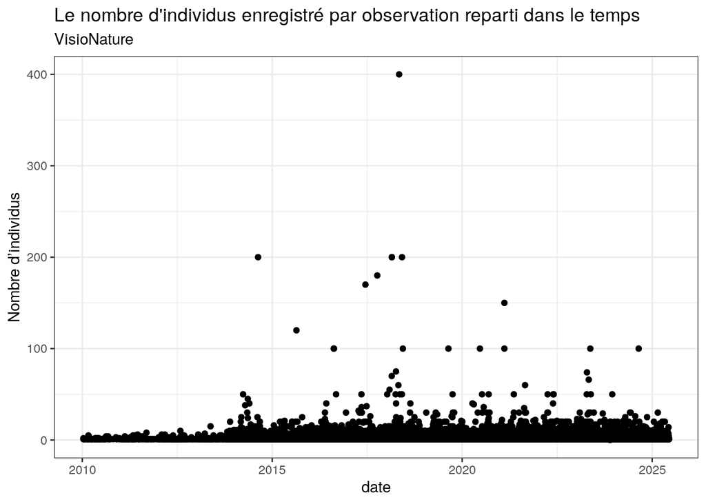

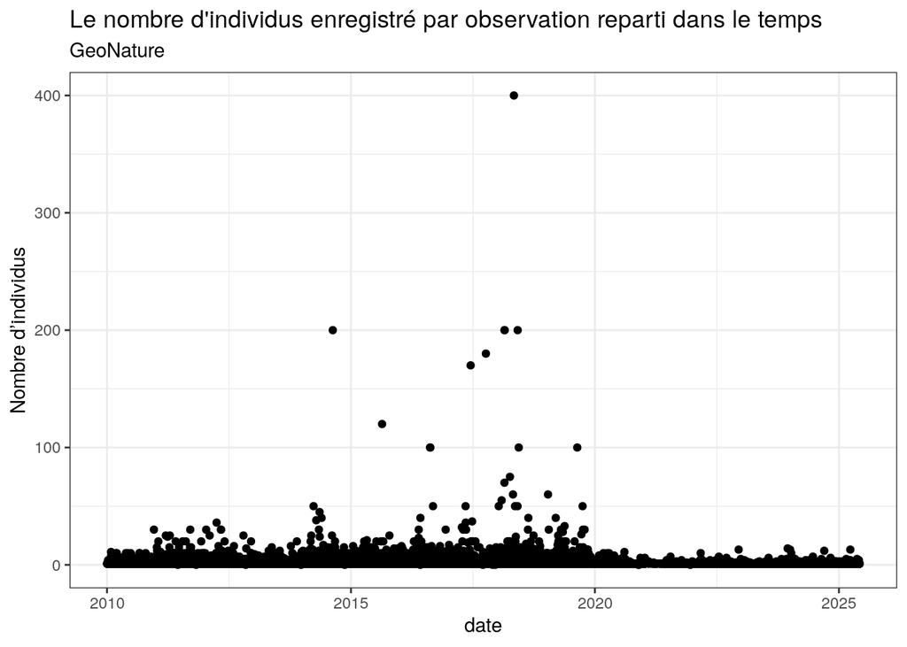

La plupart des observations ne contiennent qu’un animal mais certains en contiennent plusieurs.

Il faudrait peut-être les prendre en compte, mais les données avec beaucoup d’animaux observés (ex: 400 obs d’un coup) risquent de causer des problèmes pour créer un modèle.

Ensuite, on a essayer d’observer les proportions d’espèces dans le temps. Dans “other” il y a toutes les espèces qui représentent moins de 3% des observations de la période.

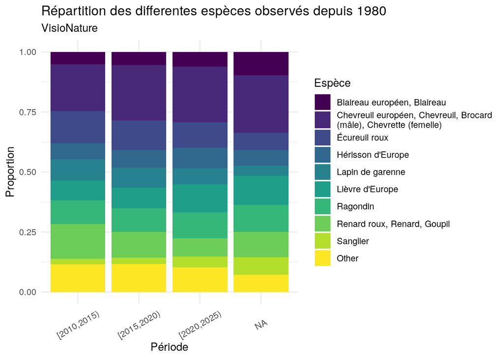

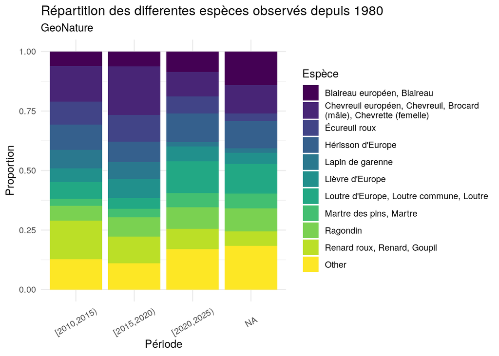

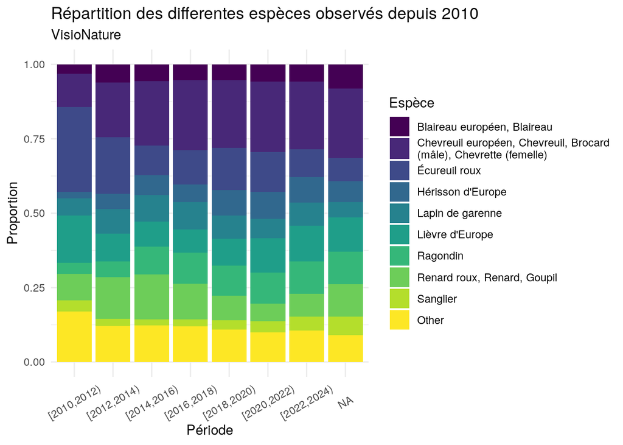

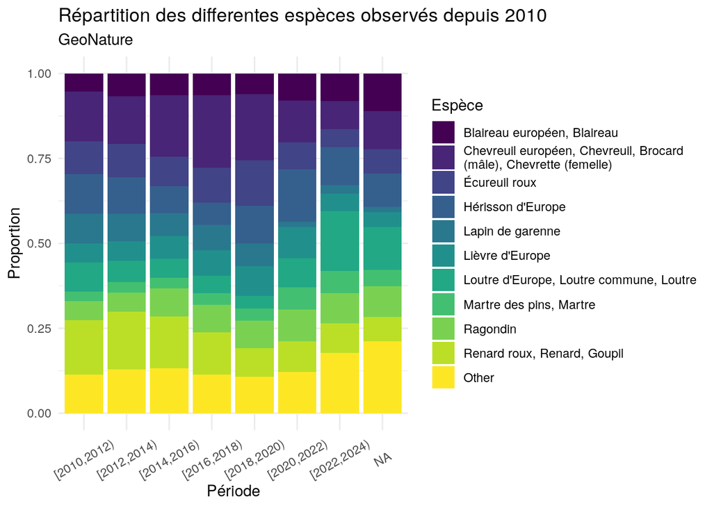

## 1.3 3. Répresentation cartographique des données

```r
# Carte bretagne
setwd("~/work/AnalyseDonneesOpportunisteGMB/donnees/DepartementsOuest")
carte_bretagne <- st_read("LIM_ADM_DepartementsOuest.shp")
carte_bretagne <- st_set_crs(carte_bretagne, 2154)
carte_bretagne <- st_transform(carte_bretagne, 4326)


# GeoNature

GN_sf <- Total_sf %>%
  filter(bdd_rgn == GN)

grid_sf <- st_sf(geometry = st_make_grid(carte_bretagne,
                                         cellsize = c(0.12, 0.09))
              )
grid_sf$density <- lengths(st_intersects(grid_sf, GN_sf))
grid_sf <- st_intersection(grid_sf, carte_bretagne)
```

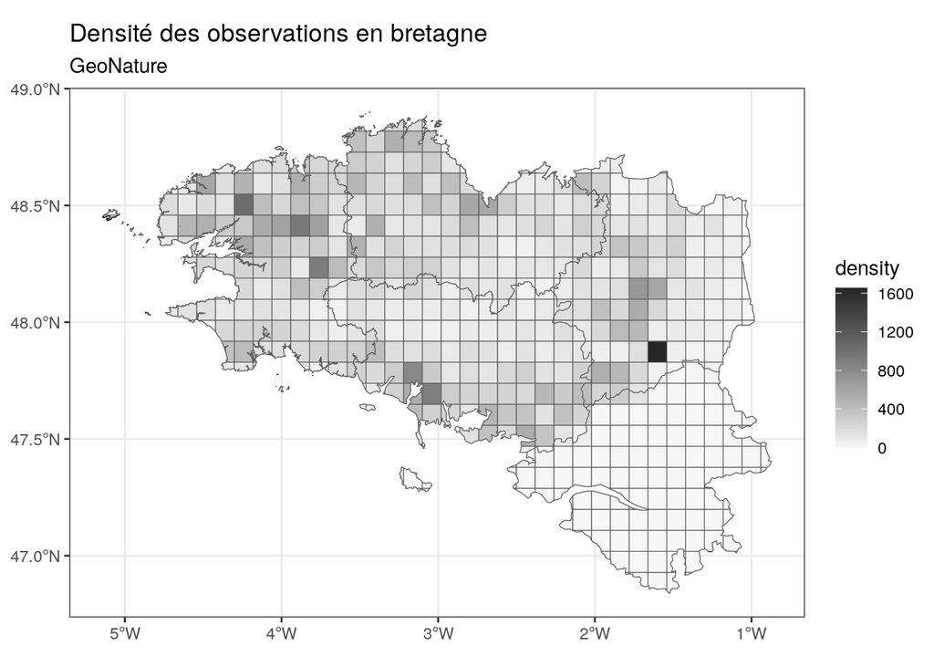

```r
ggplot() +
  geom_sf(data = carte_bretagne) +
  labs(title = "Densité des observations en bretagne",
       subtitle = GN) +
  geom_sf(data = grid_sf, aes(fill = density)) +
  scale_fill_gradient(low="gray97", high="gray15") +
  theme_bw()
```

```r
# VisioNature

VN_sf <- Total_sf %>%
  filter(bdd_rgn == VN)

grid_sf <- st_sf(geometry = st_make_grid(carte_bretagne,
                                         cellsize = c(0.12, 0.09)))
grid_sf$density <- lengths(st_intersects(grid_sf, VN_sf))
grid_sf <- st_intersection(grid_sf, carte_bretagne)
```

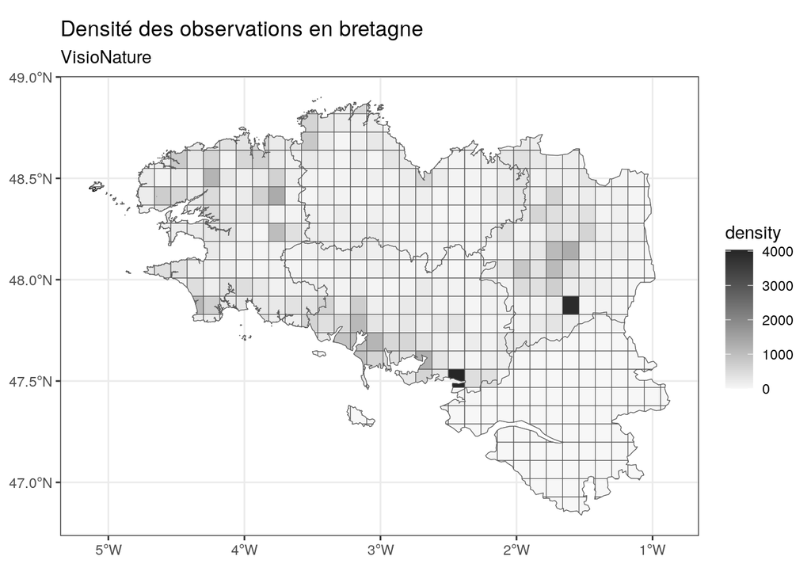

```r
ggplot() +
  geom_sf(data = carte_bretagne) +
  labs(title = "Densité des observations en bretagne",
       subtitle = VN) +
  geom_sf(data = grid_sf, aes(fill = density)) +
  scale_fill_gradient(low="grey97", high="gray15") +
  theme_bw()
```